# mcgovern_kevin

```r
# load color libraries
library(RColorBrewer)

# load ggplot
library(ggplot2)
library(gridExtra)

# load library to transform data
library(reshape2)

# add library for table styling
library(kableExtra)
```

### Test Items (50 points total)

##### (1) R has probability functions available for use (Kabacoff, Section 5.2.3). Using one distribution to approximate another is not uncommon.

(1)(a) (4 points) The Poisson distribution may be used to approximate the binomial distribution if n > 20 and np < 7. Estimate the following binomial probabilities using *dpois()* and *ppois()* with probability p = 0.05, and n = 100. Then, estimate the same probabilities using *dbinom()* and *pbinom()*. Show the numerical results of your calculations.

1. The probability of exactly 0 successes.

```r
# setup problem
q1.p = .05
q1.n = 100
q1.lamba = q1.n * q1.p

# calculate poisson approximation of 0 successes
print(paste("poisson distribution exactly 0 success: ", dpois(0, lambda = q1.lamba)))
```

```
## [1] "poisson distribution exactly 0 success:  0.00673794699908547"
```

```r
# calculate normal approximation of 0 successes
print(paste("normal distribution exactly 0 success: ", dbinom(0, q1.n, q1.p)))
```

[output not shown]

2. The probability of fewer than 6 successes.

```r
# calculate poisson approximation of less than 6 successes
print(paste("poisson distribution less than 6 success: ", ppois(5, lambda = q1.lamba)))
```

```
## [1] "poisson distribution less than 6 success:  0.615960654833063"
```

```r
# calculate normal approximation of less than 6 successes
print(paste("normal distribution less than 6 success: ", pbinom(5, q1.n, q1.p)))
```

[output not shown]

(1)(b) (2 points) Generate side-by-side barplots using *par(mfrow = c(1,2))* or *grid.arrange()*. The left barplot will show Poisson probabilties for outcomes ranging from 0 to 10. The right barplot will show binomial probabilities for outcomes ranging from 0 to 10. Use p = 0.05 and n = 100. Title each plot, present in color and assign names to the bar; i.e. x-axis value labels.

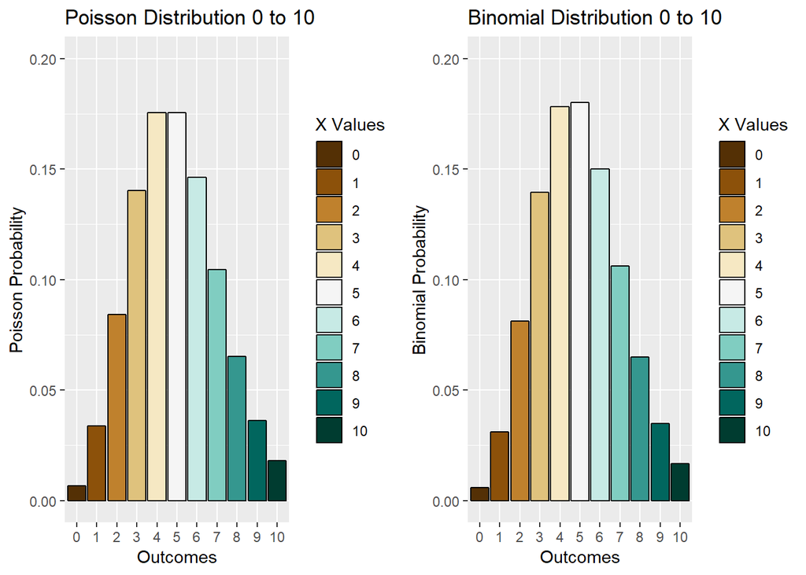

```r
# create data frame for charts
q1.df <- data.frame(xVal = factor(c(0:10)), pois = dpois(c(0:10), lambda = q1.lamba), binom = dbinom(c(0:10), q1.n, q1.p))

# create boxplot of poisson distributions for x 1 to 10
q1.PoisBloxplot <- ggplot(q1.df) +
  geom_bar(stat = "identity", aes(x = xVal, y = pois, fill = xVal), color="black") +
  ylim(0, 0.2) +
  scale_fill_brewer(palette="BrBG") +
  labs(x = "Outcomes", y="Poisson Probability", fill = "X Values", title = "Poisson Distribution 0 to 10")

# create boxplot of binomial distributions for x 1 to 10
q1.BinomBloxplot <- ggplot(q1.df) +
  geom_bar(stat = "identity", aes(x = xVal, y = binom, fill = xVal), color="black") +
  ylim(0, 0.2) +
  scale_fill_brewer(palette="BrBG") +
  labs(x = "Outcomes", y="Binomial Probability", fill = "X Values", title = "Binomial Distribution 0 to 10")

grid.arrange(q1.PoisBloxplot, q1.BinomBloxplot, ncol=2)
```

(1)(c) For this problem, refer to Sections 5.2 of Business Statistics. A discrete random variable has outcomes: 0, 1, 2, 3, 4, 5, 6. The corresponding probabilities in sequence with the outcomes are: 0.215, 0.230, 0.240, 0.182, 0.130, 0.003, 0.001. In other words, the probabilty of obtaining “0” is 0.215.

1. (2 points) Calculate the expected value and variance for this distribution using the general formula for mean and variance of a discrete distribution. To do this, you will need to use integer values from 0 to 6 as outcomes along with the corresponding probabilities. Round your answer to 2 decimal places.

```r
# setup data
q1.outcomes <- c(0, 1, 2, 3, 4, 5, 6)
q1.probabilities <- c(0.215, 0.230, 0.240, 0.182, 0.130, 0.003, 0.001)
q1.discreteDist <- data.frame(q1.outcomes, q1.probabilities)

# calculate mean or expected value
q1.expected <- sum(q1.outcomes*q1.probabilities)
print(paste("expected: ", round(q1.expected, digits = 2)))
```

```
## [1] "expected:  1.8"
```

```r
# calculate variance
q1.variance <- sum(((q1.outcomes-q1.expected)^2)*q1.probabilities)
print(paste("variance: ", round(q1.variance, digits = 2)))
```

```
## [1] "variance:  1.79"
```

2. (2 points) Use the *cumsum()* function and plot the cumulative probabilties versus the corresponding outcomes. Detemine the value of the median for this distribution and show on this plot.

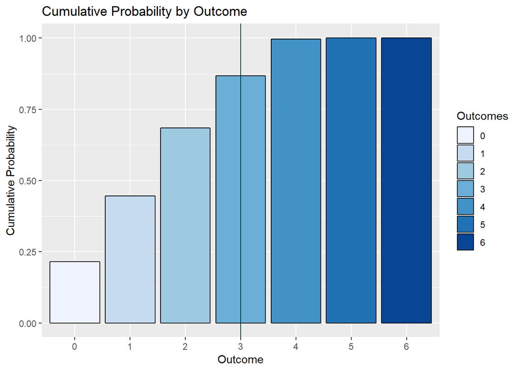

```r
# add discre distribution chart
ggplot(q1.discreteDist) +
  geom_bar(stat = "identity", aes(x = factor(q1.outcomes), y = cumsum(q1.probabilities),
                                  fill = factor(q1.outcomes)), color="black") +
  # add line for median, add one to found median because factor shifts underlying x values to 1-based
  geom_vline(xintercept = median(q1.outcomes) + 1, color = "#014636") +
  scale_fill_brewer(palette="Blues") +
  labs(x = "Outcome", y="Cumulative Probability", fill = "Outcomes", title = "Cumulative Probability by Outcome")
```

##### (2) Conditional probabilities appear in many contexts and, in particular, are used by Bayes’ Theorem. Correlations are another means for evaluating dependency between variables. The dataset “faithful”" is part of the “datasets” package and may be loaded with the statement *data(faithful)*. It contains 272 observations of 2 variables; waiting time between eruptions (in minutes) and the duration of the eruption (in minutes) for the Old Faithful geyser in Yellowstone National Park.

(2)(a) (2 points) Load the “faithful” dataset and present summary statistics and a histogram of waiting times. Additionally, compute the empirical conditional probability of an eruption less than 3.0 minutes, if the waiting time exceeds 70 minutes.

```r
data(faithful)

# print summary statistics
summary(faithful)
```

```
##    eruptions        waiting
##  Min.   :1.600   Min.   :43.0
##  1st Qu.:2.163   1st Qu.:58.0
##  Median :4.000   Median :76.0
##  Mean   :3.488   Mean   :70.9
##  3rd Qu.:4.454   3rd Qu.:82.0
##  Max.   :5.100   Max.   :96.0
```

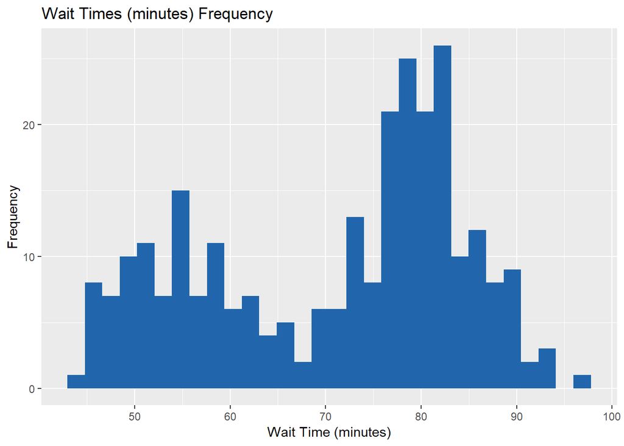

```r
# create histogram of wait times
ggplot(faithful, aes(x = waiting, color = waiting)) +
  geom_histogram(bins = 30, fill = "#2166ac") +
  scale_fill_brewer(palette="BrBG") +
  labs(x = "Wait Time (minutes)", y="Frequency", title = "Wait Times (minutes) Frequency", fill = "X Values")
```

```r
# calculate empirical probablity
q2.rowsMeetingCriteria <- faithful[(faithful$eruptions < 3.0) & (faithful$waiting > 70),]
print(paste("empirical probablity of eruption <3.0 minutes and wait time > 70 is", nrow(q2.rowsMeetingCriteria)/nrow(faithful)))
```

```
## [1] "empirical probablity of eruption <3.0 minutes and wait time > 70 is 0.00367647058823529"
```

1. (2 points) Identify any observations in “faithful” for which the waiting time exceeds 70 minutes and the eruptions are less than 3.0 minutes. List and show any such observations in a distinct color on a scatterplot of all eruption (vertical axis) and waiting times (horizontal axis). Include a horizontal line at eruption = 3.0, and a vertical line at waiting time = 70. Add a title and appropriate text.

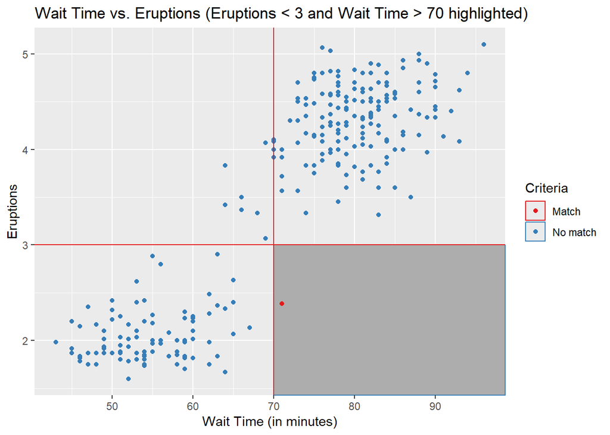

```r
# create a variable for rows matching criteria
q2.faithfulDf <- faithful
q2.faithfulDf$criteriaMatch <- ifelse((faithful$eruptions < 3.0) & (faithful$waiting > 70), "Match", "No match")

# create scatterplot of eruptions vs. wait times
ggplot(q2.faithfulDf, aes(x = waiting, y = eruptions, color = criteriaMatch)) +
  geom_rect(aes(xmin = 70, xmax = Inf, ymin = -Inf, ymax = 3), alpha = 0.1, fill = "#A9A9A9") +
  geom_point() +
  geom_vline(xintercept = 70, color = "#e41a1c") +
  geom_hline(yintercept = 3.0, color = "#e41a1c") +
  scale_color_brewer(palette="Set1") +
  labs(x = "Wait Time (in minutes)", y="Eruptions", color = "Criteria",
       title = "Wait Time vs. Eruptions (Eruptions < 3 and Wait Time > 70 highlighted)")
```

2. (1 point) What does the plot suggest about the relationship between eruption time and waiting time?

(2)(b) (3 points) Past research indicates that the waiting times between consecutive eruptions are not independent. This problem will check to see if there is evidence of this. Form consecutive pairs of waiting times. In other words, pair the first and second waiting times, pair the third and fourth waiting times, and so forth. There are 136 resulting consecutive pairs of waiting times. Form a data frame with the first column containing the first waiting time in a pair and the second column with the second waiting time in a pair. Plot the pairs with the second member of a pair on the vertical axis and the first member on the horizontal axis.

One way to do this is to pass the vector of waiting times - faithful$waiting - to *matrix()*, specifying 2 columns for our matrix, with values organized by row; i.e. byrow = TRUE.

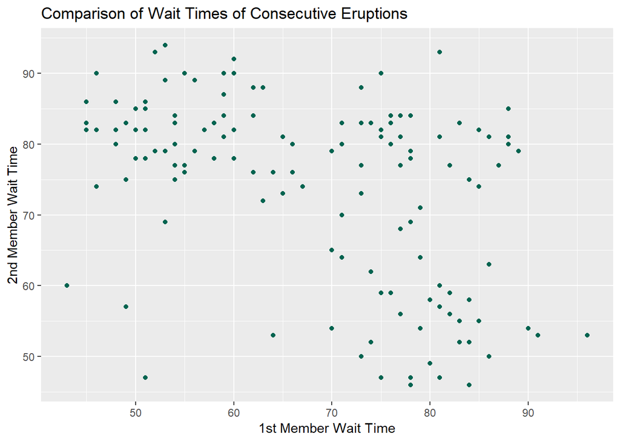

```r
# create pair number and pair column
q2.faithfulDf$pairNum <- ceiling(1:nrow(q2.faithfulDf)/2)
q2.faithfulDf$pairs <- rep(c("first", "second"), length.out=nrow(q2.faithfulDf))

# limit the columns brought in
q2.limited <- q2.faithfulDf[,c("pairNum", "pairs", "waiting")]

# melt data to ensure correct format for dcast
q2.md <- melt(q2.limited, id=c("pairNum","pairs"))
# create matched pairs and manipulate, sum used but only one value per combination found so no summarizing actually occurring
q2.matchedPairs <- dcast(q2.md, pairNum ~ pairs, fun.aggregate = sum)

# create scatterplot of 1st group vs. 2nd group wait times
ggplot(q2.matchedPairs, aes(x = first, y = second)) +
  geom_point(color = "#016450") +
  theme(legend.position = "none") +
  labs(x = "1st Member Wait Time", y="2nd Member Wait Time",
       title = "Comparison of Wait Times of Consecutive Eruptions")
```

(2)(c) (2) Test the hypothesis of independence with a two-sided test at the 5% level using the Kendall correlation coefficient.

```r
# create a Kendall correlation test
q2.kendallCorrelation <- cor.test(q2.matchedPairs$first, q2.matchedPairs$second, alternative = "two.sided", method="kendall", conf.level = 0.95)

# output results of test
q2.kendallCorrelation
```

```
##
##  Kendall's rank correlation tau
##
## data:  q2.matchedPairs$first and q2.matchedPairs$second
## z = -4.9482, p-value = 7.489e-07
## alternative hypothesis: true tau is not equal to 0
## sample estimates:
##        tau
## -0.2935579
```

```r
# print output
print(paste("The above test shows a p value of", round(q2.kendallCorrelation$p.value, 7), "which is below the alpha level of 0.05, therefore we reject the null hypothesis and accept the alternative"))
```

```
## [1] "The above test shows a p value of 7e-07 which is below the alpha level of 0.05, therefore we reject the null hypothesis and accept the alternative"
```

##### (3) Performing hypothesis tests using random samples is fundamental to statistical inference. The first part of this problem involves comparing two different diets. Using “ChickWeight” data available in the base R, “datasets” package, execute the following code to prepare a data frame for analysis.

```r
# load "ChickWeight" dataset
data(ChickWeight)

# Create T | F vector indicating observations with Time == 21 and Diet == "1" OR "3"
index <- ChickWeight$Time == 21 & (ChickWeight$Diet == "1" | ChickWeight$Diet == "3")

# Create data frame, "result," with the weight and Diet of those observations with "TRUE" "index"" values
result <- subset(ChickWeight[index, ], select = c(weight, Diet))

# Encode "Diet" as a factor
result$Diet <- factor(result$Diet)
str(result)
```

```
## Classes 'nfnGroupedData', 'nfGroupedData', 'groupedData' and 'data.frame':   26 obs. of  2 variables:
##  $ weight: num  205 215 202 157 223 157 305 98 124 175 ...
##  $ Diet  : Factor w/ 2 levels "1","3": 1 1 1 1 1 1 1 1 1 1 ...
```

##### The data frame, “result”, has chick weights for two diets, identified as diet “1” and “3”. Use the data frame, “result,” to complete the following item.

(3)(a) (2 points) Display two side-by-side vertical boxplots using par(mfrow = c(1,2)). One boxplot would display diet “1” and the other diet “3”.

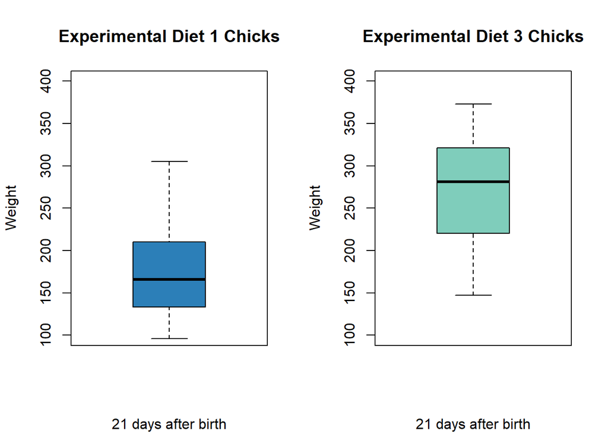

```r
q3.result1 <- result[result$Diet == 1,]
q3.result3 <- result[result$Diet == 3,]

par(mfrow = c(1,2))
# chick weight boxplot of diet 1
boxplot(q3.result1$weight, col = rgb(44, 127, 184, maxColorValue = 255),
        ylim = c(100, 400), main = "Experimental Diet 1 Chicks",
        sub = "21 days after birth", ylab = "Weight")

# chick weight boxplot of diet 3
boxplot(q3.result3$weight, col = rgb(127, 205, 187, maxColorValue = 255),
        ylim = c(100, 400), main = "Experimental Diet 3 Chicks",
        sub = "21 days after birth", ylab = "Weight")
```

(3)(b) (2 points) Use the “weight” data for the two diets to test the null hypothesis of equal population mean weights for the two diets. Test at the 95% confidence level with a two-sided t-test. This can be done using *t.test()* in R. Assume equal variances. Display the results of t.test().

```r
# test for pop weight 1 different than mean than weight 3
t.test(q3.result1$weight, q3.result3$weight, alternative = c("two.sided"), mu = 0,
       paired = FALSE, var.equal = TRUE, conf.level = .95)
```

```
##
##  Two Sample t-test
##
## data:  q3.result1$weight and q3.result3$weight
## t = -3.5955, df = 24, p-value = 0.001454
## alternative hypothesis: true difference in means is not equal to 0
## 95 percent confidence interval:
##  -145.67581  -39.42419
## sample estimates:
## mean of x mean of y
##    177.75    270.30
```

##### Working with paired data is another common statistical activity. The “ChickWeight” data will be used to illustrate how the weight gain from day 20 to 21 may be analyzed. Use the following code to prepare pre- and post-data from Diet == “3” for analysis.

```r
# load "ChickWeight" dataset
data(ChickWeight)

# Create T | F vector indicating observations with Diet == "3"
index <- ChickWeight$Diet == "3"

# Create vector of "weight" for observations where Diet == "3" and Time == 20
pre <- subset(ChickWeight[index, ], Time == 20, select = weight)$weight

# Create vector of "weight" for observations where Diet == "3" and Time == 21
post <- subset(ChickWeight[index, ], Time == 21, select = weight)$weight

# The pre and post values are paired, each pair corresponding to an individual chick.
cbind(pre, post)
```

```
##       pre post
##  [1,] 235  256
##  [2,] 291  305
##  [3,] 156  147
##  [4,] 327  341
##  [5,] 361  373
##  [6,] 225  220
##  [7,] 169  178
##  [8,] 280  290
##  [9,] 250  272
## [10,] 295  321
```

(3)(c) (2 points) Present a scatterplot of the variable “post” as a function of the variable “pre”. Include a diagonal line with zero intercept and slope equal to one. Title and label the variables in this scatterplot.

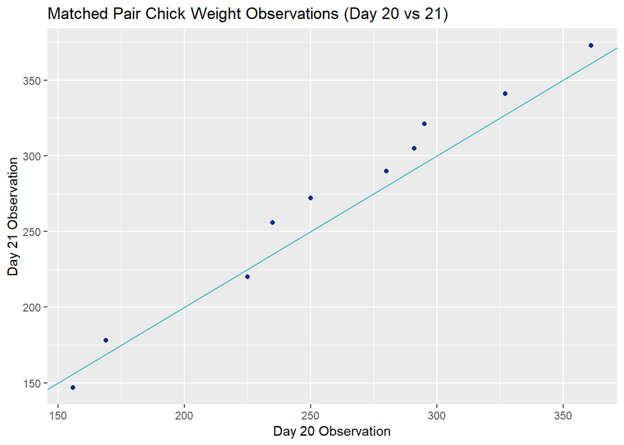

```r
# create binded data as data frame
q3.pairedData <- as.data.frame(cbind(pre, post))

# create a scatterplot of volume, split by rings
ggplot(data = q3.pairedData, aes(y = post, x = pre)) +
  geom_point(color = "#0c2c84") +
  geom_abline(intercept = 0, color = "#41b6c4") +
  theme(legend.position = "none") +
  labs(x = "Day 20 Observation", y = "Day 21 Observation", title = "Matched Pair Chick Weight Observations (Day 20 vs 21)")
```

(3)(d) (4 points) Calculate and present a one-sided, 95% confidence interval for the average weight gain from day 20 to day 21. Write the code for the paired t-test and for determination of the confidence interval endpoints. **Do not use *t.test()**, although you may check your answers using this function. Present the resulting test statistic value, critical value, p-value and confidence interval.

```r
# one tailed t-test
q3.alpha <- .05
q3.n <- nrow(q3.pairedData)
q3.degfree <- q3.n - 1
# calculate test statistic
q3.criticalValue <- qt(q3.alpha, q3.degfree, lower.tail = TRUE)
print(paste("Critical Value based on .05 alpha and df is:", q3.criticalValue))
```

```
## [1] "Critical Value based on .05 alpha and df is: -1.83311293265624"
```

```r
q3.d <- q3.pairedData$pre - q3.pairedData$post
q3.dBar <- mean(q3.d)
q3.dStdDev <- sd(q3.d)

# calculate observed t
q3.observedT <- (q3.dBar-0)/(q3.dStdDev/sqrt(q3.n))
# print critical value
print(paste("Test Statistic is:",q3.observedT))
```

```
## [1] "Test Statistic is: -3.22526710814625"
```

```r
# calculate confidence interval
q3.upperConf <- q3.dBar - q3.criticalValue * (q3.dStdDev / sqrt(q3.n))
q3.lowerConf <- q3.dBar + q3.criticalValue * (q3.dStdDev / sqrt(q3.n))
print(paste("95% Confidence Interval is ", q3.lowerConf, "to", q3.upperConf))
```

[output not shown]

```r
# Note lower confidence level is essentially equivalent to -Inf due to distribution

# calculate p value
q3.pVal <- pt(q3.observedT ,q3.degfree, lower.tail = TRUE)
print(paste("The p-value is", round(q3.pVal, digits = 5), "which is less than .05. Therefore, we reject null hypothesis and accept the alternative."))
```

```
## [1] "The p-value is 0.0052 which is less than .05. Therefore, we reject null hypothesis and accept the alternative."
```

```r
# compare to results found above
t.test(q3.pairedData$pre, q3.pairedData$post, alternative = c("less"), mu = 0,
       paired = TRUE, var.equal = TRUE, conf.level = .95)
```

```
##
##  Paired t-test
##
## data:  q3.pairedData$pre and q3.pairedData$post
## t = -3.2253, df = 9, p-value = 0.005201
## alternative hypothesis: true difference in means is less than 0
## 95 percent confidence interval:
##       -Inf -4.920696
## sample estimates:
## mean of the differences
##                   -11.4
```

##### (4) Statistical inference depends on using a sampling distribution for a statistic in order to make confidence statements about unknown population parameters. The Central Limit Theorem is used to justify use of the normal distribution as a sampling distribution for statistical inference. Using Nile River flow data from 1871 to 1970, this problem demonstrates sampling distribution convergence to normality. Use the code below to prepare the data. Refer to this example when completing (4)(c) below.

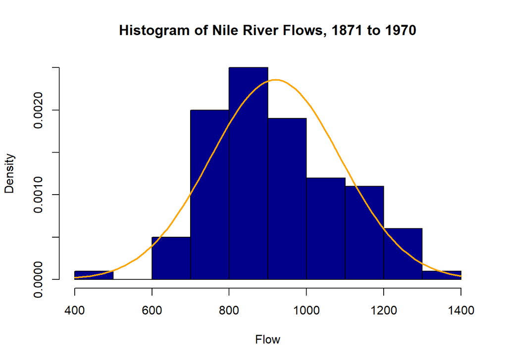

```r
data(Nile)
m <- mean(Nile)
std <- sd(Nile)

x <- seq(from = 400, to = 1400, by = 1)
hist(Nile, freq = FALSE, col = "darkblue", xlab = "Flow",
     main = "Histogram of Nile River Flows, 1871 to 1970")
curve(dnorm(x, mean = m, sd = std), col = "orange", lwd = 2, add = TRUE)
```

(4)(a) (2 points) Using Nile River flow data and the “moments” package, calculate skewness and kurtosis. Present a QQ plot and boxplot of the flow data side-by-side using *qqnorm()*, *qqline()* and *boxplot()*; *par(mfrow = c(1, 2))* may be used to locate the plots side-by-side. Add features to these displays as you choose.

```r
library(moments)
# calculate skewness and kurtosis
print(paste("Nile River flow skewness is", skewness(Nile)))
```

```
## [1] "Nile River flow skewness is 0.322369681723753"
```

```r
print(paste("Nile River flow kurtosis is", kurtosis(Nile)))
```

```
## [1] "Nile River flow kurtosis is 2.69509315497952"
```

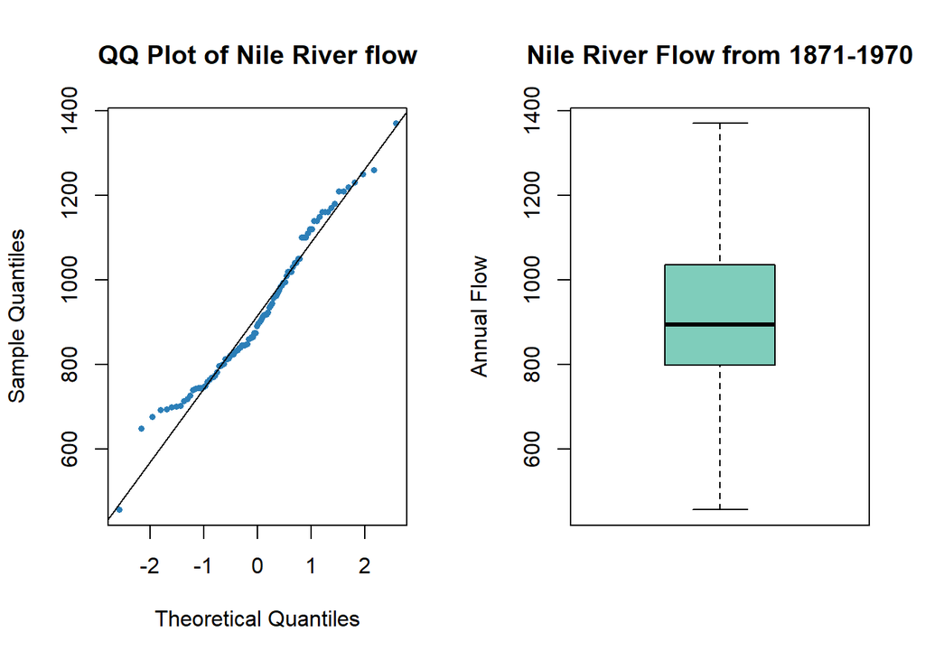

```r
par(mfrow = c(1, 2))
# create qq-norm plot - left x and y labels off because default labels sufficiently describes representation
qqnorm(Nile, col = rgb(44, 127, 184, maxColorValue = 255),
       cex = 0.6, pch = 16,
       main = "QQ Plot of Nile River flow")
qqline(Nile)
# nile river flow boxplot
boxplot(Nile, col = rgb(127, 205, 187, maxColorValue = 255),
        main = "Nile River Flow from 1871-1970",
        ylab = "Annual Flow")
```

(4)(b) (4 points) Using *set.seed(124)* and the Nile data, generate 1000 random samples of size n = 16, with replacement. For each sample drawn, calculate and store the sample mean. This can be done with a for-loop and use of the *sample()* function. Label the resulting 1000 mean values as “sample1”. **Repeat these steps using *set.seed(127)* - a different “seed” - and samples of size n = 64.** Label these 1000 mean values as “sample2”. Compute and present the means, sample standard deviations and sample variances for “sample1” and “sample2” in a table with the first row for “sample1”, the second row for “sample2” and the columns labled for each statistic.

```r
# create a vector with all values from start to length of data set
q4.nileIntVector <- c(1:length(Nile))

# create function to run through iterations
getSampleStats <- function(iterations, sampleSize, seed) {
  # create list
  q4.datalist = list()

  set.seed(seed)

  # loop through 1000 samples
  for (i in 1:iterations) {
      # get sample
      q4.sample <- sample(q4.nileIntVector, sampleSize)

      # store sample mean
      q4.dat <- data.frame(mean = mean(q4.sample))
      # store iteration number
      q4.dat$i <- i
      q4.datalist[[i]] <- q4.dat # add it to your list
  }
  return(q4.datalist)
}
# call function to get list of stats of sample size 16, seed 124
q4.listOfSamples1 <- getSampleStats(1000, 16, 124)
# flatten list into data frame
sample1 = do.call(rbind, q4.listOfSamples1)

# call function to get list of stats of sample size 16, seed 127
q4.listOfSamples1 <- getSampleStats(1000, 64, 127)
# flatten list into data frame
sample2 = do.call(rbind, q4.listOfSamples1)

# calculate mean, standard devision, and variance for each of the two sample means
sample1stats <- data.frame(Sample = 1, Mean = mean(sample1$mean), Standard_Deviation = sd(sample1$mean), Variance = var(sample1$mean))
sample2stats <- data.frame(Sample = 2, Mean = mean(sample2$mean), Standard_Deviation = sd(sample2$mean), Variance = var(sample2$mean))

# output table of statistics for both samples
kable(rbind(sample1stats, sample2stats), format = "html", caption = "Extreme Ratio Outliers Determined by Sex") %>% kable_styling()
```

| Sample | Mean | Standard_Deviation | Variance |
| --- | --- | --- | --- |
| 1 | 50.55519 | 6.788486 | 46.083542 |
| 2 | 50.53303 | 2.147184 | 4.610399 |

(4)(c) (4 points) Present side-by-side histograms of “sample1” and “sample2” with the normal density curve superimposed. To prepare comparable histograms, it will be necessary to use “freq = FALSE” and to maintain the same x-axis with “xlim = c(750, 1050)”, and the same y-axis with “ylim = c(0, 0.025).” **To superimpose separate density functions, you will need to use the mean and standard deviation for each “sample” - each histogram - separately.**

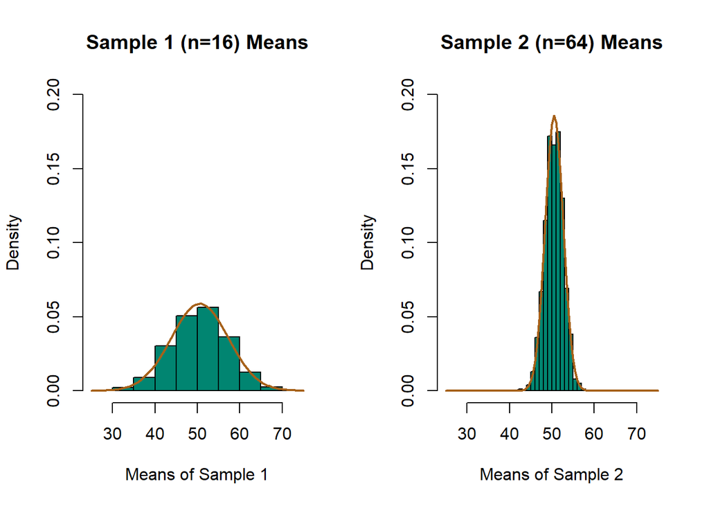

```r
x <- c(1:1000)

par(mfrow = c(1, 2))
# create histogram for first sample
hist(sample1$mean, freq = FALSE, col = "#018571", xlab = "Means of Sample 1",
     ylim = c(0,0.2), xlim = c(25, 75), main = "Sample 1 (n=16) Means")
curve(dnorm(x, mean = sample1stats$Mean, sd = sample1stats$Standard_Deviation), col = "#a6611a", lwd = 2, add = TRUE)

# create histogram for second sample, squished because standard deviation is much smaller
hist(sample2$mean, freq = FALSE, col = "#018571", xlab = "Means of Sample 2",
     ylim = c(0,0.2), xlim = c(25, 75), main = "Sample 2 (n=64) Means")
curve(dnorm(x, mean = sample2stats$Mean, sd = sample2stats$Standard_Deviation), col = "#a6611a", lwd = 2, add = TRUE)
```

##### (5) This problem deals with contingency table analysis. This is an example of categorical data analysis (see Kabacoff, pp. 145-151). The “warpbreaks” dataset gives the number of warp breaks per loom, where a loom corresponds to a fixed length of yarn. There are 54 observations on 3 variables: breaks (numeric, the number of breaks), wool (factor, type of wool: A or B), and tension (factor, low L, medium M and high H). These data have been studied and used for example elsewhere. For the purposes of this problem, we will focus on the relationship between breaks and tension using contingency table analysis.

(5)(a)(3 points) warpbreaks is part of the “datasets” package and may be loaded via *data(warpbreaks)*. Load “warpbreaks” and present the structure using *str()*. Calculate the median number of breaks for the entire dataset, disregarding “tension” and “wool”. Define this median value as “median_breaks”. Present a histogram of the number of breaks with the location of the median indicated.

Create a new variable “number” as follows: for each value of “breaks”, classify the number of breaks as either strictly below “median_breaks”, or the alternative. Convert the “above”|“below” classifications to a factor, and combine with the dataset warpbreaks. Present a summary of the augmented dataset using *summary()*. Present a contingency table of the frequency of breaks using the two variables “tension” and “number”. There should be six cells in this table.

```r
data(warpbreaks)
str(warpbreaks)
```

```
## 'data.frame':    54 obs. of  3 variables:
##  $ breaks : num  26 30 54 25 70 52 51 26 67 18 ...
##  $ wool   : Factor w/ 2 levels "A","B": 1 1 1 1 1 1 1 1 1 1 ...
##  $ tension: Factor w/ 3 levels "L","M","H": 1 1 1 1 1 1 1 1 1 2 ...
```

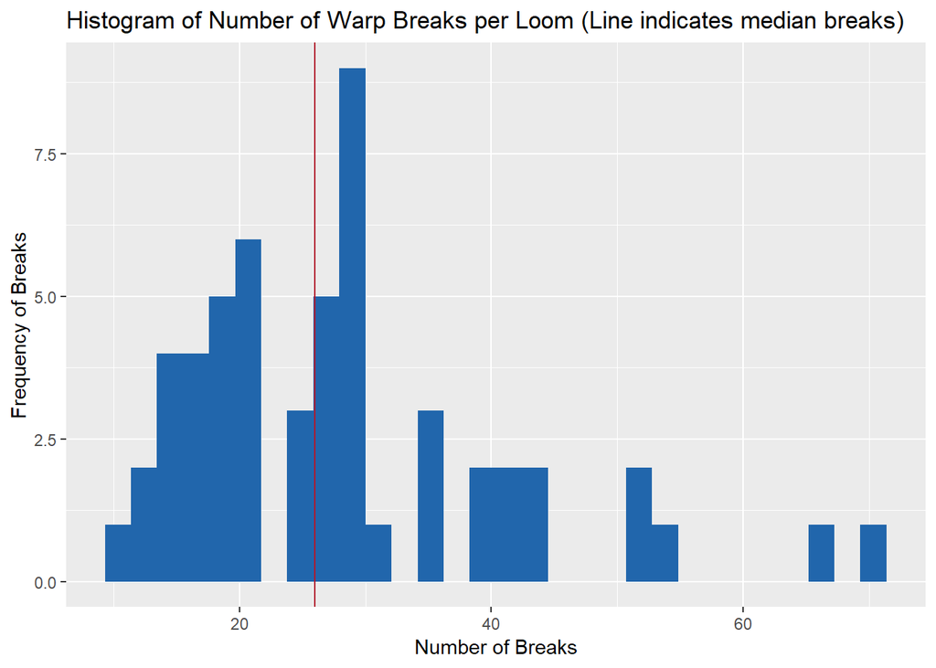

```r
# calculate median breaks
median_breaks <- median(warpbreaks$breaks)

# create a scatterplot of volume, split by rings
ggplot(data = warpbreaks, aes(x = breaks)) +
  geom_histogram(bins = 30, fill = "#2166ac") +
  geom_vline(xintercept = median_breaks, color = "#b2182b") +
  theme(legend.position = "none") +
  labs(x = "Number of Breaks", y = "Frequency of Breaks", title = "Histogram of Number of Warp Breaks per Loom (Line indicates median breaks)")
```

```r
# if-else to create variable for number
number <- ifelse((warpbreaks$breaks < median_breaks), "Below", "Above")

# add back to data set
warpbreaks$number <- factor(number)

# print summary of warpbreaks
summary(warpbreaks)
```

```
##      breaks      wool   tension   number
##  Min.   :10.00   A:27   L:18    Above:29
##  1st Qu.:18.25   B:27   M:18    Below:25
##  Median :26.00          H:18
##  Mean   :28.15
##  3rd Qu.:34.00
##  Max.   :70.00
```

```r
# output contingency table
q5.contingencyTable <- table(warpbreaks$tension, warpbreaks$number)
q5.contingencyTable
```

```
##
##     Above Below
##   L    14     4
##   M    10     8
##   H     5    13
```

(5)(b)(2 points) Using the table constructed in (5)(a), test at the 5% level the null hypothesis of independence using the uncorrected *chisq.test()* (Black, Business Statistics, Section 16.2). Show the results of this test and state your conclusions.

```r
q5.chisq <- chisq.test(q5.contingencyTable)
q5.chisq
```

```
##
##  Pearson's Chi-squared test
##
## data:  q5.contingencyTable
## X-squared = 9.0869, df = 2, p-value = 0.01064
```

```r
print(paste("With a p-value of", q5.chisq$p.value, "we should reject the hypothesis at the 5% level, and accept the alternative."))
```

```
## [1] "With a p-value of 0.0106366650871008 we should reject the hypothesis at the 5% level, and accept the alternative."
```

(5)(c) (5 points) Write a function that computes the uncorrected Pearson Chi-squared statistic. Apply your function to the table from (5)(a). You should be able to duplicate the X-squared value (chi-squared) and *p*-value. Present both.

Shown below are examples of the type of function required. These examples will have to be modified to accomodate the table generated in (5)(a).

```r
# create function for calculating chisq values
chisqfun <- function(t) {
  x <- addmargins(t)
  e <- matrix(0, nrow = nrow(t), ncol = ncol(t), byrow = T)
  r <- matrix(0, nrow = nrow(t), ncol = ncol(t), byrow = T)
  # Loop by row (over total number of rows first)
  for (i in 1:nrow(t)) {
    # Nested loop to loop over each column
    for (j in 1:ncol(t)) {
      e[i,j] = x[nrow(x),j] * x[i,ncol(x)]/x[nrow(x), ncol(x)]
      r[i,j] = ((x[i,j] - e[i,j])^2)/e[i,j]
    }
  }
  # summarize all cells for chi-square stat
  chi <- sum(r)
  # calculate degrees of freedom
  xdf <- nrow(t) - 1
  # calculate p-value
  pv <- pchisq(chi, df = xdf, lower.tail = FALSE)
  cat("\nPearson's Chi-squared test \n\n","X-squared = ", chi, ", df = ",xdf,", p-value = ",pv, sep = "")
  invisible(list(p.value = pv, statistic = chi, parameter = xdf))
}
# assign user defined function and print output
q5.userDefinedChisq <- chisqfun(q5.contingencyTable)
```

```
##
## Pearson's Chi-squared test
##
## X-squared = 9.086897, df = 2, p-value = 0.01063667
```

```r
# output original test
q5.chisq
```

```
##
##  Pearson's Chi-squared test
##
## data:  q5.contingencyTable
## X-squared = 9.0869, df = 2, p-value = 0.01064
```

```r
# compare two tests
print(paste("Compare the output above of the user defined function to the output generated by the chisq.test function. User defined p value of", q5.userDefinedChisq$p.value, "vs", q5.chisq$p.value, "and chi-squared of", q5.userDefinedChisq$statistic, "vs", q5.chisq$statistic))
```

```
## [1] "Compare the output above of the user defined function to the output generated by the chisq.test function. User defined p value of 0.0106366650871008 vs 0.0106366650871008 and chi-squared of 9.08689655172414 vs 9.08689655172414"
```